# 0101_Sentinel1_vv_vh_angle_corrected

### Nairobi Flood Footprints by Katie, Helen & Ezra

## Part 1: Data Acquisition + Preprocessing

Sentinel-1 is a pair of Synthetic Aperture Radar (SAR) imaging satellites launched in 2014 and 2016 by the European Space Agency (ESA). Their 6 day revisit cycle and ability to observe through clouds makes this dataset perfect for sea and land monitoring, emergency response due to environmental disasters, and economic applications. This dataset represents the global Sentinel-1 GRD archive, from beginning to the present, converted to cloud-optimized GeoTIFF format.

```python
from pathlib import Path
# Imports
from datetime import datetime, timedelta

import geopandas as gpd
import matplotlib.pyplot as plt
import numpy as np
# !pip install odc-stac
# !pip install pystac-client
# !pip install rioxarray
# !pip install xarray
# !pip install dask
# !pip install shapely
import odc.stac
import pystac_client
import rioxarray
import xarray as xr
# !pip install "dask[distributed]"
from dask.distributed import Client
from matplotlib.patches import Patch
from odc.geo.geobox import GeoBox
from skimage.filters import threshold_otsu

PROJECT_DIR = Path.cwd()
if PROJECT_DIR.name == "notebooks":
    PROJECT_DIR = PROJECT_DIR.parent
elif not (PROJECT_DIR / "data").exists() and (PROJECT_DIR / "FinalProjects" / "data").exists():
    PROJECT_DIR = PROJECT_DIR / "FinalProjects"
client = Client(processes=False)
```

```python
# Define spatial and temporal extent
dx = 0.0003  # ~30m resolution
epsg = 4326

# Nairobi area bounds
#-1.5371°, 36.5134° : -1.0918°, 37.2744°
latmin, latmax = -1.5371, -1.0918
lonmin, lonmax = 36.5134, 37.2744
bounds = (lonmin, latmin, lonmax, latmax)

# Temporal extent: May 2026
#start_date = datetime(year=2026, month=3, day=1)
#end_date = start_date + timedelta(days=20)

# Temporal extent: April 2024
start_date = datetime(year=2024, month=3, day=6)
end_date = datetime(year=2024, month=6, day=1)

time_format = "%Y-%m-%d"
date_query = f"{start_date.strftime(time_format)}/{end_date.strftime(time_format)}"

# Search for Sentinel-1 data
items = (
    pystac_client.Client.open("https://earth-search.aws.element84.com/v1")
    .search(
        bbox=bounds,
        collections=["sentinel-1-grd"],
        datetime=date_query,
        limit=100,
        query={"sar:instrument_mode": {"in": ["IW"]}},
    )
    .item_collection()
)
print(f"{len(items)} scenes found")
```

```
15 scenes found
```

```python
import os
os.environ['AWS_NO_SIGN_REQUEST'] = 'YES'

# Create geobox and load Sentinel-1 VV/VH together.
# Earth Search's sentinel-1-grd collection does not expose an incidence-angle raster,
# so angle-related vertical banding is corrected empirically in the next cell.
geobox = GeoBox.from_bbox(bounds, crs=f"epsg:{epsg}", resolution=dx)

dc_raw = odc.stac.load(
    items,
    bands=["vv", "vh"],
    geobox=geobox,
    resampling="bilinear",
)

dc_raw
```

```
<xarray.Dataset> Size: 226MB
Dimensions:      (latitude: 1485, longitude: 2537, time: 15)
Coordinates:
  * latitude     (latitude) float64 12kB -1.092 -1.092 -1.092 ... -1.537 -1.537
  * longitude    (longitude) float64 20kB 36.51 36.51 36.51 ... 37.27 37.27
    spatial_ref  int32 4B 4326
  * time         (time) datetime64[ns] 120B 2024-03-07T15:56:40.945631 ... 20...
Data variables:
    vv           (time, latitude, longitude) uint16 113MB 121 106 101 ... 0 0 0
    vh           (time, latitude, longitude) uint16 113MB 62 58 49 48 ... 0 0 0
```

### Angle / Stripe-Aware Raw Preprocessing

This section converts Sentinel-1 backscatter to dB and removes broad column-wise brightness bias before baseline differencing. This is an empirical replacement for incidence-angle correction because the Earth Search `sentinel-1-grd` STAC items used here do not provide an `angle` raster asset.

```python
# Preprocess raw Sentinel-1 before computing the flood baseline.
# This reduces the vertical brightness bands caused by incidence angle / swath geometry.

def _spatial_dims(da):
    non_time_dims = [d for d in da.dims if d != "time"]
    if len(non_time_dims) != 2:
        raise ValueError(f"Expected one time dim and two spatial dims, got {da.dims}")
    y_dim = "y" if "y" in da.dims else non_time_dims[0]
    x_dim = "x" if "x" in da.dims else non_time_dims[1]
    return y_dim, x_dim


def to_db(da):
    """Convert positive linear backscatter to dB."""
    return 10 * np.log10(da.where(da > 0))


def remove_column_brightness_bias(da_db, window=121):
    """
    Empirical incidence-angle / stripe normalization.

    For each acquisition, estimate the large-scale x-direction brightness profile
    using the median over rows. Subtract that profile while preserving the scene
    median. This reduces vertical bands before before/after differencing.
    """
    y_dim, x_dim = _spatial_dims(da_db)
    scene_median = da_db.median(dim=(y_dim, x_dim), skipna=True)
    column_profile = da_db.median(dim=y_dim, skipna=True)
    smooth_profile = column_profile.rolling({x_dim: window}, center=True, min_periods=1).median()
    correction = smooth_profile - scene_median
    return da_db - correction


dc_db = xr.Dataset(
    {
        "vv": to_db(dc_raw.vv),
        "vh": to_db(dc_raw.vh),
    },
    attrs=dc_raw.attrs,
)

dc = xr.Dataset(
    {
        "vv": remove_column_brightness_bias(dc_db.vv),
        "vh": remove_column_brightness_bias(dc_db.vh),
    },
    attrs=dc_raw.attrs,
)

before = dc.sel(time=slice("2024-03-06", "2024-04-06"))
after = dc.sel(time=slice("2024-05-01", "2024-06-01"))
before_raw = dc_raw.sel(time=slice("2024-03-06", "2024-04-06"))
after_raw = dc_raw.sel(time=slice("2024-05-01", "2024-06-01"))

print(f"Before scenes: {before.sizes.get('time', 0)}")
print(f"After scenes: {after.sizes.get('time', 0)}")
dc
```

```
Before scenes: 5
After scenes: 6
```

```
<xarray.Dataset> Size: 452MB
Dimensions:      (latitude: 1485, longitude: 2537, time: 15)
Coordinates:
  * latitude     (latitude) float64 12kB -1.092 -1.092 -1.092 ... -1.537 -1.537
  * longitude    (longitude) float64 20kB 36.51 36.51 36.51 ... 37.27 37.27
    spatial_ref  int32 4B 4326
  * time         (time) datetime64[ns] 120B 2024-03-07T15:56:40.945631 ... 20...
Data variables:
    vv           (time, latitude, longitude) float32 226MB 20.99 20.41 ... nan
    vh           (time, latitude, longitude) float32 226MB 18.02 17.74 ... nan
```

### Raw vs Corrected Sentinel-1 Diagnostics

Use this diagnostic to check whether the three vertical brightness bands are reduced before running the flood baseline.

```python
raw_before_vh_db = to_db(before_raw.vh).median(dim="time", skipna=True)
raw_after_vh_db = to_db(after_raw.vh).median(dim="time", skipna=True)
corr_before_vh = before.vh.median(dim="time", skipna=True)
corr_after_vh = after.vh.median(dim="time", skipna=True)
```

```python
print(raw_before_vh_db)
print(raw_after_vh_db)
print(corr_before_vh)
print(corr_after_vh)

print("raw_before nan count:", np.isnan(raw_before_vh_db.values).sum())
print("raw_after nan count:", np.isnan(raw_after_vh_db.values).sum())
print("corr_before nan count:", np.isnan(corr_before_vh.values).sum())
print("corr_after nan count:", np.isnan(corr_after_vh.values).sum())

print("raw_before min/max:", np.nanmin(raw_before_vh_db.values), np.nanmax(raw_before_vh_db.values))
print("raw_after min/max:", np.nanmin(raw_after_vh_db.values), np.nanmax(raw_after_vh_db.values))
print("corr_before min/max:", np.nanmin(corr_before_vh.values), np.nanmax(corr_before_vh.values))
print("corr_after min/max:", np.nanmin(corr_after_vh.values), np.nanmax(corr_after_vh.values))
```

```
<xarray.DataArray 'vh' (latitude: 1485, longitude: 2537)> Size: 15MB
array([[17.923916, 17.63428 , 16.90196 , ..., 19.138138, 20.11832 ,
        20.939013],
       [17.708519, 17.403625, 17.160032, ..., 19.635569, 20.169529,
        21.085049],
       [17.708519, 17.403625, 16.720978, ..., 20.211697, 20.334236,
        20.790455],
       ...,
       [18.38849 , 17.853298, 17.853298, ..., 19.514908, 19.659832,
        19.361364],
       [18.260748, 17.853298, 17.853298, ..., 19.26484 , 19.310658,
        19.286663],
       [18.19544 , 18.0618  , 17.63428 , ..., 18.802866, 19.068573,
        19.62527 ]], dtype=float32)
Coordinates:
  * latitude     (latitude) float64 12kB -1.092 -1.092 -1.092 ... -1.537 -1.537
  * longitude    (longitude) float64 20kB 36.51 36.51 36.51 ... 37.27 37.27
    spatial_ref  int32 4B 4326
<xarray.DataArray 'vh' (latitude: 1485, longitude: 2537)> Size: 15MB
array([[19.542425, 19.29419 , 18.573324, ..., 19.777237, 20.530785,
        21.367207],
       [19.344984, 19.19078 , 18.260748, ..., 19.590414, 20.453228,
        21.846914],
       [19.08485 , 19.29419 , 18.450981, ..., 20.49218 , 20.89905 ,
        22.06826 ],
       ...,
       [19.29419 , 19.4939  , 19.138138, ..., 19.68483 , 19.4939  ,
        19.731277],
       [19.731277, 19.4939  , 19.4939  , ..., 19.444826, 19.29419 ,
        19.395193],
       [19.867718, 19.395193, 18.864906, ..., 19.242794, 19.242794,
        19.344984]], dtype=float32)
Coordinates:
  * latitude     (latitude) float64 12kB -1.092 -1.092 -1.092 ... -1.537 -1.537
  * longitude    (longitude) float64 20kB 36.51 36.51 36.51 ... 37.27 37.27
    spatial_ref  int32 4B 4326
<xarray.DataArray 'vh' (latitude: 1485, longitude: 2537)> Size: 15MB
array([[18.02492 , 17.735283, 17.021751, ..., 18.864473, 19.844656,
        20.665348],
       [17.956755, 17.651861, 17.369371, ..., 19.361904, 19.895866,
```

[output cut: 25 more lines]

```
        19.395193],
       [19.955458, 19.4876  , 18.900543, ..., 19.355604, 19.355604,
        19.457794]], dtype=float32)
Coordinates:
  * latitude     (latitude) float64 12kB -1.092 -1.092 -1.092 ... -1.537 -1.537
  * longitude    (longitude) float64 20kB 36.51 36.51 36.51 ... 37.27 37.27
    spatial_ref  int32 4B 4326
raw_before nan count: 0
raw_after nan count: 0
corr_before nan count: 0
corr_after nan count: 0
raw_before min/max: 14.313639 34.61048
raw_after min/max: 14.313639 33.935753
corr_before min/max: 14.228894 34.559685
corr_after min/max: 14.401379 33.84975
```

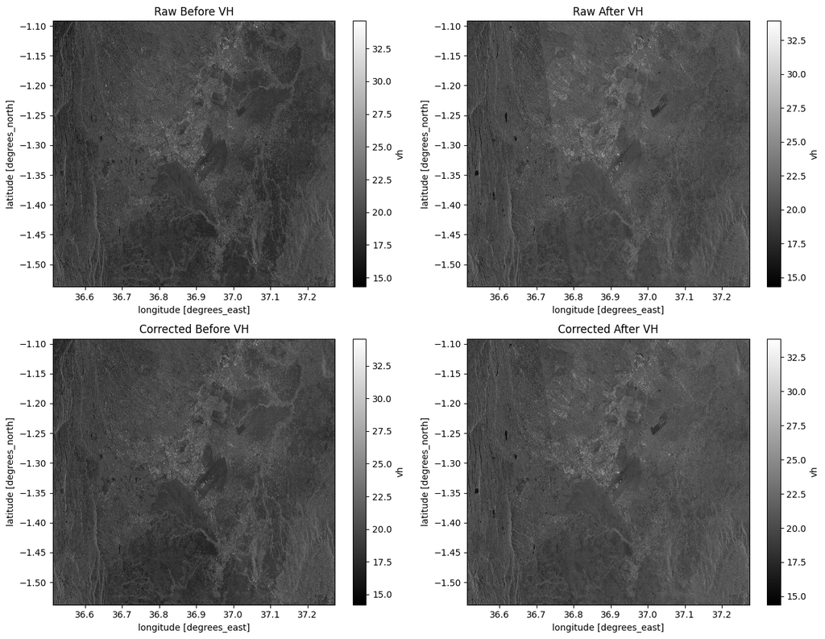

```python
fig, axs = plt.subplots(2, 2, figsize=(13, 10))

raw_before_vh_db.plot(ax=axs[0, 0], cmap="gray")
raw_after_vh_db.plot(ax=axs[0, 1], cmap="gray")
corr_before_vh.plot(ax=axs[1, 0], cmap="gray")
corr_after_vh.plot(ax=axs[1, 1], cmap="gray")

axs[0, 0].set_title("Raw Before VH")
axs[0, 1].set_title("Raw After VH")
axs[1, 0].set_title("Corrected Before VH")
axs[1, 1].set_title("Corrected After VH")
plt.tight_layout()
plt.show()
```

```python
print("before_raw.vh min/max:", float(before_raw.vh.min()), float(before_raw.vh.max()))
print("after_raw.vh min/max:", float(after_raw.vh.min()), float(after_raw.vh.max()))
print("before.vh min/max:", float(before.vh.min()), float(before.vh.max()))
print("after.vh min/max:", float(after.vh.min()), float(after.vh.max()))
```

```
before_raw.vh min/max: 0.0 6664.0
after_raw.vh min/max: 0.0 6512.0
before.vh min/max: 13.901497840881348 37.78838348388672
after.vh min/max: 14.014710426330566 37.880523681640625
```

```python
# Before/after periods are now created from the corrected `dc` dataset in the preprocessing cell above.
# Keeping this cell as a reminder of the selected flood windows.
print("Before window: 2024-03-06 to 2024-04-06")
print("After window: 2024-05-01 to 2024-06-01")
```

```
Before window: 2024-03-06 to 2024-04-06
After window: 2024-05-01 to 2024-06-01
```

```python
import ee
ee.Authenticate()
```

```
True
```

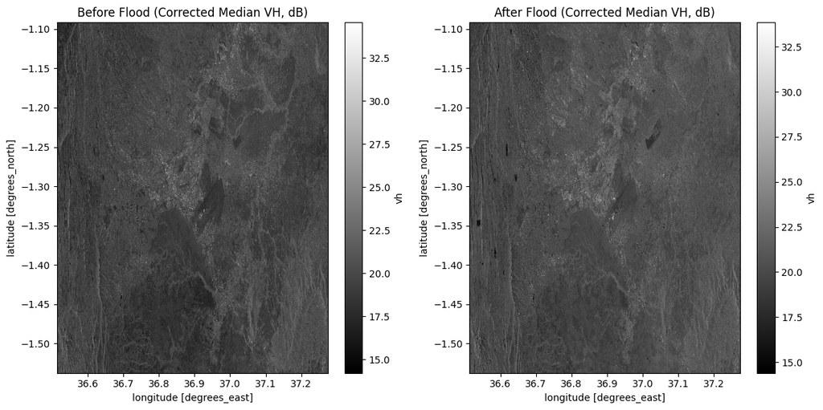

```python
before_vh_composite = before.vh.median(dim="time", skipna=True)
after_vh_composite = after.vh.median(dim="time", skipna=True)

fig, axs = plt.subplots(1, 2, figsize=(12, 6))
before_vh_composite.plot(ax=axs[0], cmap="gray")
after_vh_composite.plot(ax=axs[1], cmap="gray")

axs[0].set_title("Before Flood (Corrected Median VH, dB)")
axs[1].set_title("After Flood (Corrected Median VH, dB)")
plt.tight_layout()
plt.show()
```

```python
print('Before Flood (Corrected Median VH dB) Statistics:')
print(f'  Min: {before_vh_composite.min().item():.4f}')
print(f'  Max: {before_vh_composite.max().item():.4f}')
print(f'  Mean: {before_vh_composite.mean().item():.4f}')

print('\nAfter Flood (Corrected Median VH dB) Statistics:')
print(f'  Min: {after_vh_composite.min().item():.4f}')
print(f'  Max: {after_vh_composite.max().item():.4f}')
print(f'  Mean: {after_vh_composite.mean().item():.4f}')
```

```
Before Flood (Corrected Median VH dB) Statistics:
  Min: 14.2289
  Max: 34.5597
  Mean: 19.7330

After Flood (Corrected Median VH dB) Statistics:
  Min: 14.4014
  Max: 33.8498
  Mean: 20.3928
```

```python
before_95th_percentile = np.nanpercentile(before_vh_composite.values, 95)
after_95th_percentile = np.nanpercentile(after_vh_composite.values, 95)

print(f'Before Flood (Corrected Median VH dB) 95th percentile: {before_95th_percentile:.4f}')
print(f'After Flood (Corrected Median VH dB) 95th percentile: {after_95th_percentile:.4f}')
```

```
Before Flood (Corrected Median VH dB) 95th percentile: 21.5836
After Flood (Corrected Median VH dB) 95th percentile: 21.9560
```

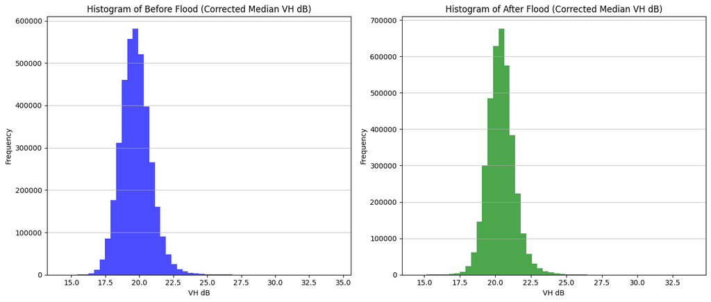

```python
fig, axs = plt.subplots(1, 2, figsize=(14, 6))

before_data_flat = before_vh_composite.values.flatten()
before_data_flat = before_data_flat[~np.isnan(before_data_flat)]
after_data_flat = after_vh_composite.values.flatten()
after_data_flat = after_data_flat[~np.isnan(after_data_flat)]

axs[0].hist(before_data_flat, bins=50, color='blue', alpha=0.7)
axs[0].set_title('Histogram of Before Flood (Corrected Median VH dB)')
axs[0].set_xlabel('VH dB')
axs[0].set_ylabel('Frequency')
axs[0].grid(axis='y', alpha=0.75)

axs[1].hist(after_data_flat, bins=50, color='green', alpha=0.7)
axs[1].set_title('Histogram of After Flood (Corrected Median VH dB)')
axs[1].set_xlabel('VH dB')
axs[1].set_ylabel('Frequency')
axs[1].grid(axis='y', alpha=0.75)

plt.tight_layout()
plt.show()
```

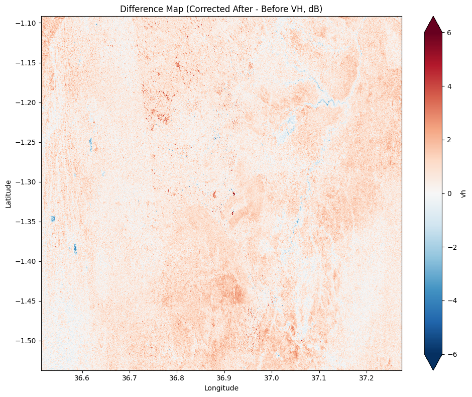

```python
# Baseline flood signal: corrected after - before in dB.
# Negative values indicate a decrease in backscatter, which is consistent with open water.
difference = after_vh_composite - before_vh_composite

plt.figure(figsize=(10, 8))
difference.plot(cmap="RdBu_r", vmin=-6, vmax=6)
plt.title("Difference Map (Corrected After - Before VH, dB)")
plt.xlabel("Longitude")
plt.ylabel("Latitude")
plt.tight_layout()
plt.show()
```

```python
before_99th_percentile = np.nanpercentile(before_vh_composite.values, 99)
after_99th_percentile = np.nanpercentile(after_vh_composite.values, 99)

print(f'Before Flood (Corrected Median VH dB) 99th percentile: {before_99th_percentile:.4f}')
print(f'After Flood (Corrected Median VH dB) 99th percentile: {after_99th_percentile:.4f}')
```

```
Before Flood (Corrected Median VH dB) 99th percentile: 22.7027
After Flood (Corrected Median VH dB) 99th percentile: 23.0828
```

### Create a Binary Flood Mask

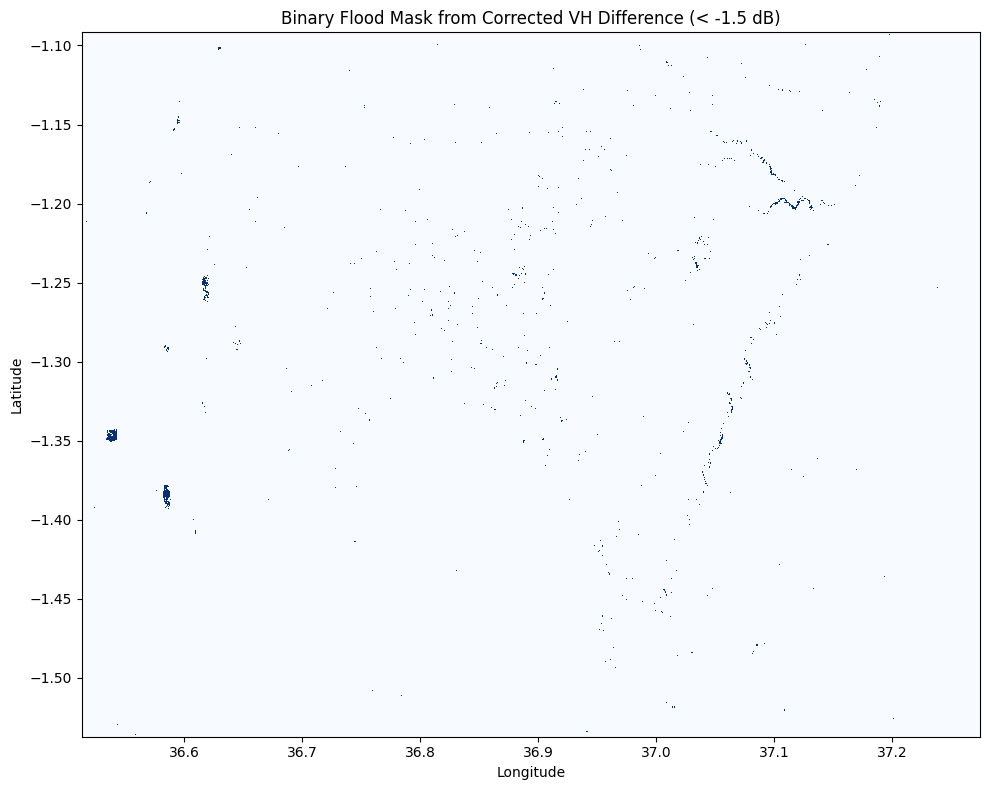

```python
# Corrected dB difference: flooding/open water is usually a negative backscatter change.
flood_threshold = -1.5
flood_mask = difference < flood_threshold

plt.figure(figsize=(10, 8))
flood_mask.plot(cmap="Blues", add_colorbar=False)
plt.title(f"Binary Flood Mask from Corrected VH Difference (< {flood_threshold} dB)")
plt.xlabel("Longitude")
plt.ylabel("Latitude")
plt.tight_layout()
plt.show()
```

### Determining Flood Threshold using Otsu's Method

Otsu's method is a popular approach for automatically performing histogram-based image thresholding. It aims to find the threshold that minimizes the intra-class variance (the variance within the foreground and background classes) or, equivalently, maximizes the inter-class variance (the variance between the two classes). In our case, it will help us automatically distinguish between 'flooded' and 'non-flooded' areas based on the `difference` in VH backscatter.

```
Otsu's threshold for corrected VH dB difference: 0.6716
```

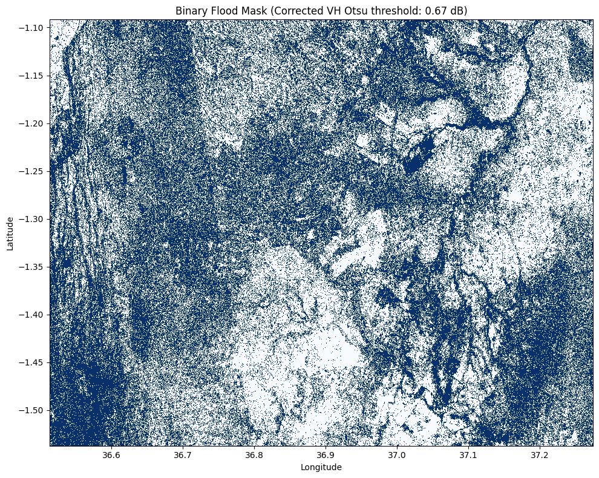

```python
difference_flat = difference.values.flatten()
difference_flat = difference_flat[~np.isnan(difference_flat)]

Q1 = np.percentile(difference_flat, 25)
Q3 = np.percentile(difference_flat, 75)
IQR = Q3 - Q1
lower_bound = Q1 - 1.5 * IQR
upper_bound = Q3 + 1.5 * IQR

difference_filtered = difference_flat[(difference_flat >= lower_bound) & (difference_flat <= upper_bound)]
otsu_threshold = threshold_otsu(difference_filtered)

print(f"Otsu's threshold for corrected VH dB difference: {otsu_threshold:.4f}")
flood_mask_otsu = difference < otsu_threshold

plt.figure(figsize=(10, 8))
flood_mask_otsu.plot(cmap="Blues", add_colorbar=False)
plt.title(f"Binary Flood Mask (Corrected VH Otsu threshold: {otsu_threshold:.2f} dB)")
plt.xlabel("Longitude")
plt.ylabel("Latitude")
plt.tight_layout()
plt.show()
```

```python
!pip install contextily
```

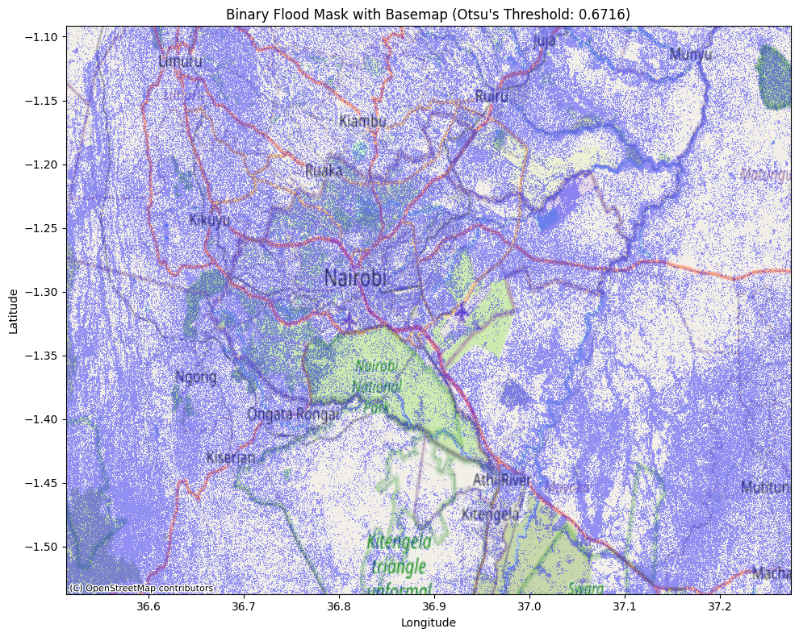

```python
import contextily as cx
from matplotlib.colors import ListedColormap

# Create a custom colormap: transparent for non-flood (0), semi-transparent blue for flood (1)
# The RGBA format is (red, green, blue, alpha), where alpha is transparency (0=transparent, 1=opaque)
colors = [(0, 0, 0, 0), (0, 0, 1, 0.4)]  # Transparent for 0, 40% opaque blue for 1
cmap_custom = ListedColormap(colors)

fig, ax = plt.subplots(1, 1, figsize=(10, 8))

# Plot the binary flood mask using the custom transparent colormap
flood_mask_otsu.plot(ax=ax, cmap=cmap_custom, add_colorbar=False)

cx.add_basemap(ax, crs=flood_mask_otsu.spatial_ref.crs_wkt, source=cx.providers.OpenStreetMap.Mapnik)

plt.title(f"Binary Flood Mask with Basemap (Otsu's Threshold: {otsu_threshold:.4f})")
plt.xlabel("Longitude")
plt.ylabel("Latitude")
plt.tight_layout()
plt.show()
```

We have used vh SAR values, next we'll proceed with exploring flood extents using the VV band

```python
# VV is already loaded and corrected in `dc`; no separate reload is needed.
dc_vv = dc[["vv"]]
dc_vv
```

```
<xarray.Dataset> Size: 226MB
Dimensions:      (time: 15, latitude: 1485, longitude: 2537)
Coordinates:
  * latitude     (latitude) float64 12kB -1.092 -1.092 -1.092 ... -1.537 -1.537
  * longitude    (longitude) float64 20kB 36.51 36.51 36.51 ... 37.27 37.27
    spatial_ref  int32 4B 4326
  * time         (time) datetime64[ns] 120B 2024-03-07T15:56:40.945631 ... 20...
Data variables:
    vv           (time, latitude, longitude) float32 226MB 20.99 20.41 ... nan
```

```python
before_vv = dc_vv.sel(time=slice("2024-03-06", "2024-04-06"))
after_vv = dc_vv.sel(time=slice("2024-05-01", "2024-06-01"))

before_vv_composite = before_vv.vv.median(dim="time", skipna=True)
after_vv_composite = after_vv.vv.median(dim="time", skipna=True)
```

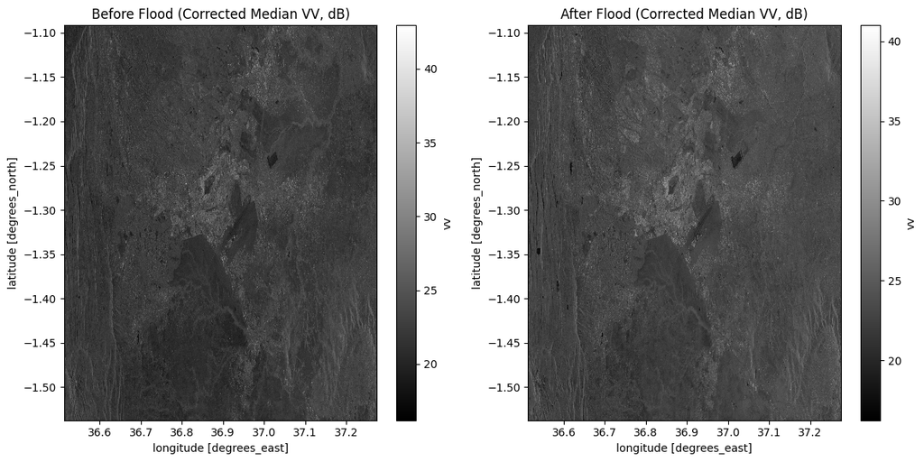

```python
fig_vv, axs_vv = plt.subplots(1, 2, figsize=(12, 6))
before_vv_composite.plot(ax=axs_vv[0], cmap="gray")
after_vv_composite.plot(ax=axs_vv[1], cmap="gray")

axs_vv[0].set_title("Before Flood (Corrected Median VV, dB)")
axs_vv[1].set_title("After Flood (Corrected Median VV, dB)")
plt.tight_layout()
plt.show()
```

```python
print('Before Flood (Corrected Median VV dB) Statistics:')
print(f'  Min: {before_vv_composite.min().item():.4f}')
print(f'  Max: {before_vv_composite.max().item():.4f}')
print(f'  Mean: {before_vv_composite.mean().item():.4f}')

print('\nAfter Flood (Corrected Median VV dB) Statistics:')
print(f'  Min: {after_vv_composite.min().item():.4f}')
print(f'  Max: {after_vv_composite.max().item():.4f}')
print(f'  Mean: {after_vv_composite.mean().item():.4f}')
```

```
Before Flood (Corrected Median VV dB) Statistics:
  Min: 16.2008
  Max: 42.9435
  Mean: 22.5625

After Flood (Corrected Median VV dB) Statistics:
  Min: 16.2432
  Max: 40.9988
  Mean: 23.2628
```

```python
before_vv_95th_percentile = np.nanpercentile(before_vv_composite.values, 95)
after_vv_95th_percentile = np.nanpercentile(after_vv_composite.values, 95)

print(f'Before Flood (Corrected Median VV dB) 95th percentile: {before_vv_95th_percentile:.4f}')
print(f'After Flood (Corrected Median VV dB) 95th percentile: {after_vv_95th_percentile:.4f}')

before_vv_99th_percentile = np.nanpercentile(before_vv_composite.values, 99)
after_vv_99th_percentile = np.nanpercentile(after_vv_composite.values, 99)
print(f'Before Flood (Corrected Median VV dB) 99th percentile: {before_vv_99th_percentile:.4f}')
print(f'After Flood (Corrected Median VV dB) 99th percentile: {after_vv_99th_percentile:.4f}')
```

```
Before Flood (Corrected Median VV dB) 95th percentile: 24.8103
After Flood (Corrected Median VV dB) 95th percentile: 25.3265
Before Flood (Corrected Median VV dB) 99th percentile: 26.4909
After Flood (Corrected Median VV dB) 99th percentile: 26.9371
```

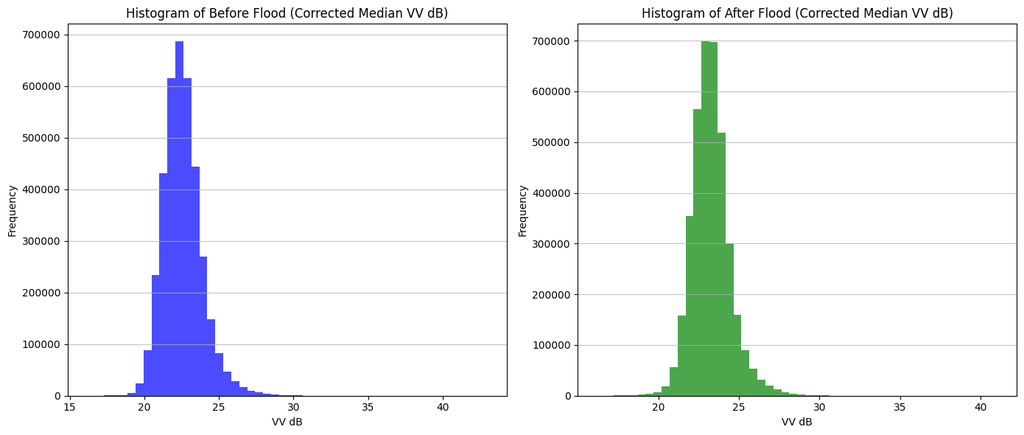

```python
fig_hist_vv, axs_hist_vv = plt.subplots(1, 2, figsize=(14, 6))

before_vv_data_flat = before_vv_composite.values.flatten()
before_vv_data_flat = before_vv_data_flat[~np.isnan(before_vv_data_flat)]
after_vv_data_flat = after_vv_composite.values.flatten()
after_vv_data_flat = after_vv_data_flat[~np.isnan(after_vv_data_flat)]

axs_hist_vv[0].hist(before_vv_data_flat, bins=50, color='blue', alpha=0.7)
axs_hist_vv[0].set_title('Histogram of Before Flood (Corrected Median VV dB)')
axs_hist_vv[0].set_xlabel('VV dB')
axs_hist_vv[0].set_ylabel('Frequency')
axs_hist_vv[0].grid(axis='y', alpha=0.75)

axs_hist_vv[1].hist(after_vv_data_flat, bins=50, color='green', alpha=0.7)
axs_hist_vv[1].set_title('Histogram of After Flood (Corrected Median VV dB)')
axs_hist_vv[1].set_xlabel('VV dB')
axs_hist_vv[1].set_ylabel('Frequency')
axs_hist_vv[1].grid(axis='y', alpha=0.75)

plt.tight_layout()
plt.show()
```

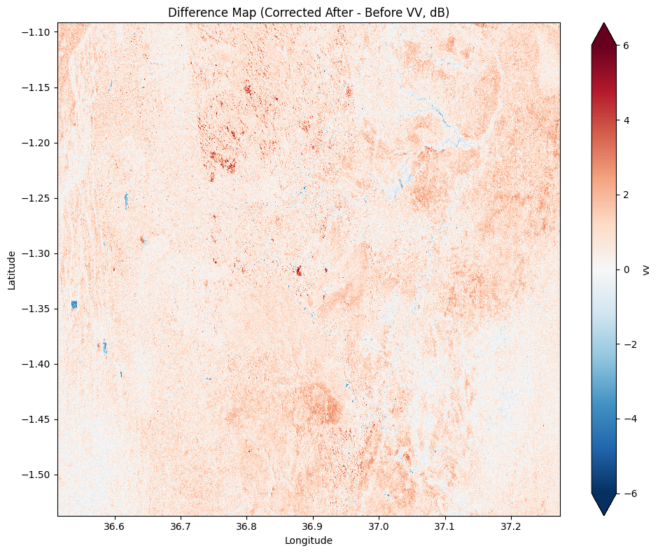

```python
difference_vv = after_vv_composite - before_vv_composite

plt.figure(figsize=(10, 8))
difference_vv.plot(cmap="RdBu_r", vmin=-6, vmax=6)
plt.title("Difference Map (Corrected After - Before VV, dB)")
plt.xlabel("Longitude")
plt.ylabel("Latitude")
plt.tight_layout()
plt.show()
```

### Create a Binary Flood Mask (VV Band)

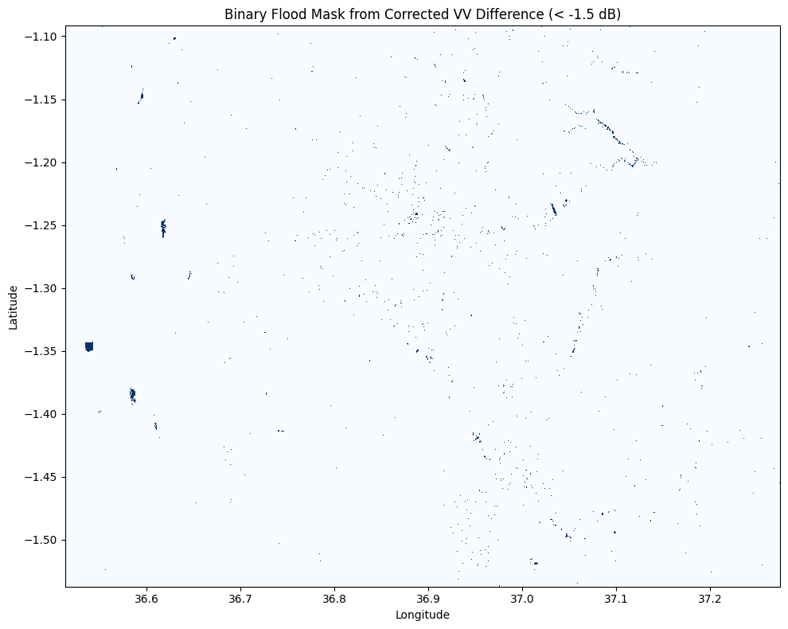

```python
flood_threshold_vv = -1.5
flood_mask_vv = difference_vv < flood_threshold_vv

plt.figure(figsize=(10, 8))
flood_mask_vv.plot(cmap="Blues", add_colorbar=False)
plt.title(f"Binary Flood Mask from Corrected VV Difference (< {flood_threshold_vv} dB)")
plt.xlabel("Longitude")
plt.ylabel("Latitude")
plt.tight_layout()
plt.show()
```

### Determining Flood Threshold using Otsu's Method (VV Band)

We will now apply Otsu's method to the `difference_vv` map to automatically find a suitable threshold for flood detection in the VV band. This method helps to minimize intra-class variance and maximize inter-class variance, providing an objective way to distinguish between flooded and non-flooded areas.

```
Otsu's threshold for corrected VV dB difference: 0.7168
```

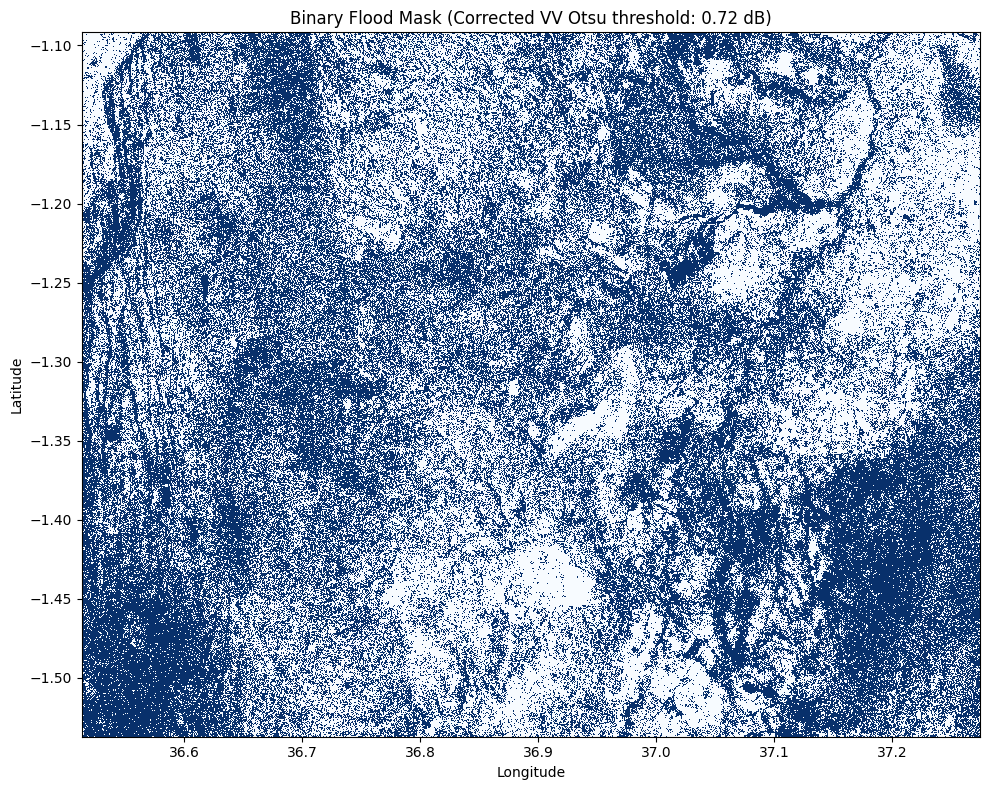

```python
difference_vv_flat = difference_vv.values.flatten()
difference_vv_flat = difference_vv_flat[~np.isnan(difference_vv_flat)]

Q1_vv = np.percentile(difference_vv_flat, 25)
Q3_vv = np.percentile(difference_vv_flat, 75)
IQR_vv = Q3_vv - Q1_vv
lower_bound_vv = Q1_vv - 1.5 * IQR_vv
upper_bound_vv = Q3_vv + 1.5 * IQR_vv

difference_vv_filtered = difference_vv_flat[(difference_vv_flat >= lower_bound_vv) & (difference_vv_flat <= upper_bound_vv)]
otsu_threshold_vv = threshold_otsu(difference_vv_filtered)

print(f"Otsu's threshold for corrected VV dB difference: {otsu_threshold_vv:.4f}")
flood_mask_otsu_vv = difference_vv < otsu_threshold_vv

plt.figure(figsize=(10, 8))
flood_mask_otsu_vv.plot(cmap="Blues", add_colorbar=False)
plt.title(f"Binary Flood Mask (Corrected VV Otsu threshold: {otsu_threshold_vv:.2f} dB)")
plt.xlabel("Longitude")
plt.ylabel("Latitude")
plt.tight_layout()
plt.show()
```

[figure not shown]

```python
import contextily as cx
from matplotlib.colors import ListedColormap

# Create a custom colormap: transparent for non-flood (0), semi-transparent blue for flood (1)
# The RGBA format is (red, green, blue, alpha), where alpha is transparency (0=transparent, 1=opaque)
colors_vv = [(0, 0, 0, 0), (0, 0, 1, 0.4)]  # Transparent for 0, 40% opaque blue for 1
cmap_custom_vv = ListedColormap(colors_vv)

fig_vv_map, ax_vv_map = plt.subplots(1, 1, figsize=(10, 8))

# Plot the binary flood mask using the custom transparent colormap for VV band
flood_mask_otsu_vv.plot(ax=ax_vv_map, cmap=cmap_custom_vv, add_colorbar=False)

cx.add_basemap(ax=ax_vv_map, crs=flood_mask_otsu_vv.spatial_ref.crs_wkt, source=cx.providers.OpenStreetMap.Mapnik)

plt.title(f"Binary Flood Mask (VV) with Basemap (Otsu's Threshold: {otsu_threshold_vv:.4f})")
plt.xlabel("Longitude")
plt.ylabel("Latitude")
plt.tight_layout()
plt.show()
```

This is the ground truth data from Google Research for the floods across the globe from media reports. It contains polygons of flooded areas with their start and end dates, as well as their area in km2. We will use this data to evaluate our flood extent maps derived from Sentinel-1. SAR data

```python
groundtruth_drive = gpd.read_parquet(PROJECT_DIR / "data" / "groundsource__2026.parquet")
print(groundtruth_drive.head())
```

```
                               uuid    area_km2  \
0  5acc1866dd6644dfa572f02ae3d54aa4   91.678015
1  f80fccbefb1346a9b568907086e65226  609.968365
2  d5c49c9e2c2045bfbfd6e3b3865efc3f    0.099688
3  ce7f01a29de040b39e138f198fc39d86    0.548906
4  eb047dfea9ed406485010853226e0170    0.236562

                                            geometry  start_date    end_date
0  MULTIPOLYGON (((8.64252 53.60898, 8.65179 53.6...  2000-01-01  2000-01-01
1  MULTIPOLYGON (((-0.01457 51.65825, -0.00151 51...  2000-01-01  2000-01-01
2  POLYGON ((-58.43034 -34.61363, -58.42461 -34.6...  2000-01-24  2000-01-24
3  POLYGON ((23.44227 47.63646, 23.43369 47.6408,...  2000-01-30  2000-01-30
4  POLYGON ((-57.54008 -38.00748, -57.5575 -38.02...  2000-01-30  2000-01-30
```

```python
import pandas as pd
from shapely.geometry import box
groundtruth_drive["start_date"] = pd.to_datetime(groundtruth_drive["start_date"])
groundtruth_drive["end_date"]   = pd.to_datetime(groundtruth_drive["end_date"])
nairobi_box = box(lonmin, latmin, lonmax, latmax)
groundtruth_drive = groundtruth_drive[
    (groundtruth_drive["area_km2"] > 5) &
    (groundtruth_drive["area_km2"] <= 600)
    & (groundtruth_drive.geometry.within(nairobi_box))
    & (groundtruth_drive["start_date"].dt.year == 2024)

].copy()

print(groundtruth_drive.shape)
```

```
(102, 5)
```

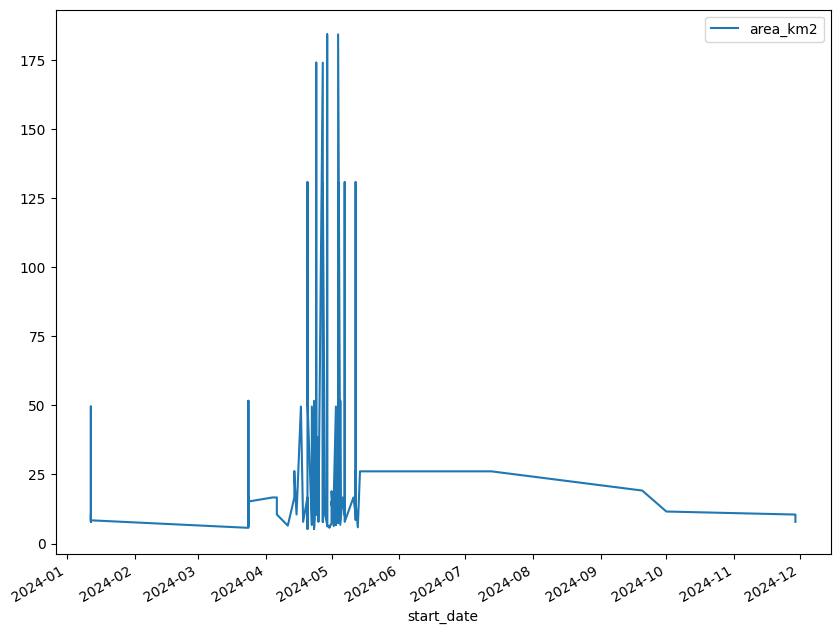

```python
groundtruth_drive.plot(kind="line", x="start_date", y="area_km2", figsize=(10, 8))
```

```python
groundtruth_drive.explore(column="area_km2", cmap="viridis", figsize=(10, 8))
```

Make this Notebook Trusted to load map: File -> Trust Notebook

[interactive chart not shown]

### Binary Flood Mask (VH) with Basemap and Ground Truth Overlay

[figure not shown]

```python
import contextily as cx
from matplotlib.colors import ListedColormap
from matplotlib.patches import Patch

# Create a custom colormap: transparent for non-flood (0), semi-transparent blue for flood (1)
colors = [(0, 0, 0, 0), (0, 0, 1, 0.4)]  # Transparent for 0, 40% opaque blue for 1
cmap_custom = ListedColormap(colors)

fig_vh_gt, ax_vh_gt = plt.subplots(1, 1, figsize=(10, 8))

# Plot the binary flood mask using the custom transparent colormap
flood_mask_otsu.plot(ax=ax_vh_gt, cmap=cmap_custom, add_colorbar=False)

# Overlay groundtruth polygons with no fill
groundtruth_drive.plot(ax=ax_vh_gt, facecolor='none', edgecolor='red', alpha=0.8, label='Ground Truth Floods', zorder=2) # zorder to ensure it's on top

cx.add_basemap(ax=ax_vh_gt, crs=flood_mask_otsu.spatial_ref.crs_wkt, source=cx.providers.OpenStreetMap.Mapnik)

ax_vh_gt.set_title(f"Binary Flood Mask (VH) with Basemap and Ground Truth (Otsu's Threshold: {otsu_threshold:.4f})")
ax_vh_gt.set_xlabel("Longitude")
ax_vh_gt.set_ylabel("Latitude")

# Create a custom legend handle for the ground truth polygons
ground_truth_legend = Patch(facecolor='none', edgecolor='red', alpha=0.8, label='Ground Truth Floods')
# Create a custom legend handle for the flood mask
flood_mask_legend = Patch(color='blue', alpha=0.4, label='Detected Flood (VH)')
ax_vh_gt.legend(handles=[ground_truth_legend, flood_mask_legend])

plt.tight_layout()
plt.show()
```

### Binary Flood Mask (VV) with Basemap and Ground Truth Overlay

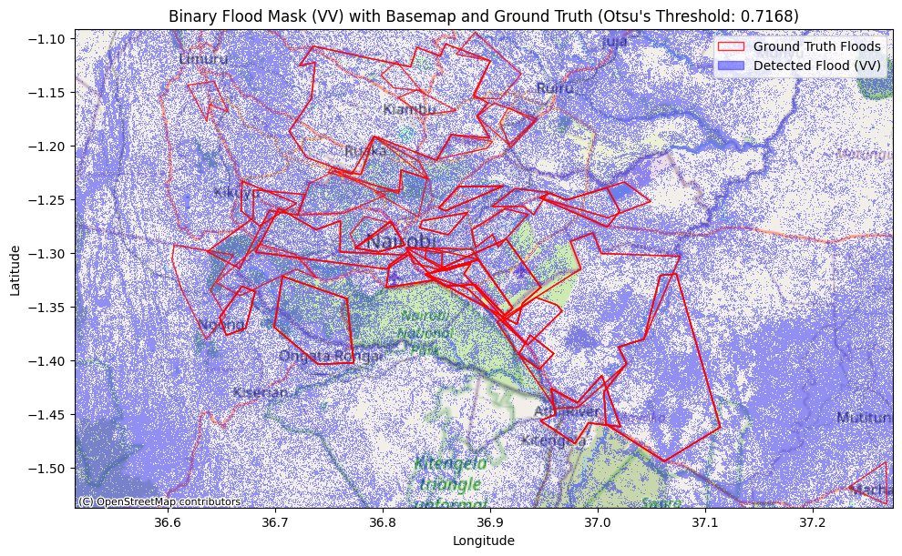

```python
import contextily as cx
from matplotlib.colors import ListedColormap
from matplotlib.patches import Patch

# Create a custom colormap: transparent for non-flood (0), semi-transparent blue for flood (1)
colors_vv = [(0, 0, 0, 0), (0, 0, 1, 0.4)]  # Transparent for 0, 40% opaque blue for 1
cmap_custom_vv = ListedColormap(colors_vv)

fig_vv_gt, ax_vv_gt = plt.subplots(1, 1, figsize=(10, 8))

# Plot the binary flood mask using the custom transparent colormap for VV band
flood_mask_otsu_vv.plot(ax=ax_vv_gt, cmap=cmap_custom_vv, add_colorbar=False)

# Overlay groundtruth polygons with no fill
groundtruth_drive.plot(ax=ax_vv_gt, facecolor='none', edgecolor='red', alpha=0.8, label='Ground Truth Floods', zorder=2) # zorder to ensure it's on top

cx.add_basemap(ax=ax_vv_gt, crs=flood_mask_otsu_vv.spatial_ref.crs_wkt, source=cx.providers.OpenStreetMap.Mapnik)

ax_vv_gt.set_title(f"Binary Flood Mask (VV) with Basemap and Ground Truth (Otsu's Threshold: {otsu_threshold_vv:.4f})")
ax_vv_gt.set_xlabel("Longitude")
ax_vv_gt.set_ylabel("Latitude")

# Create a custom legend handle for the ground truth polygons
ground_truth_legend = Patch(facecolor='none', edgecolor='red', alpha=0.8, label='Ground Truth Floods')
# Create a custom legend handle for the flood mask
flood_mask_vv_legend = Patch(color='blue', alpha=0.4, label='Detected Flood (VV)')
ax_vv_gt.legend(handles=[ground_truth_legend, flood_mask_vv_legend])

plt.tight_layout()
plt.show()
```